# Project Data Visualization

# 1 Worldwide repartition of the data

In this section, the aim is to understand how observations are distributed globally, both spatially and temporally. This distribution matters because it directly shapes how the rest of the dataset should be interpreted: an over-representation of certain regions may reflect sampling bias (the activity of contributors in the field) rather than the true state of global tree biodiversity. It is therefore essential to characterize where and when the data was collected, and to identify areas of high and low sampling density. We start by examining the overall geographical spread of observations across continents, before looking more closely at how taxonomic diversity (families, genus, species) is distributed in space. Finally, we analyze how sampling effort has evolved over time, both globally and by continent, to assess whether spatial biases have shifted across the years.

## 1.1 Pre-Processing

For this analysis, observations are grouped by continent rather than by country. With data spanning more than 210 countries, a country-level analysis would fragment the dataset into categories too small and numerous to reveal meaningful patterns, while a continent-level grouping provides a small number of interpretable regions, each large enough to support robust comparisons of taxonomic diversity and temporal trends. The continent for each observation was derived by spatially joining the point coordinates (longitude, latitude) with a world countries shapefile (rnaturalearth). This approach, however, relies on administrative continent boundaries, which do not always align with the geographical logic relevant to this study. Two adjustments were therefore necessary:

- Russia is administratively classified as a single entity, but spans two geographical continents. Observations were reassigned to Europe or Asia based on the conventional Ural Mountains boundary (60°E longitude).
- Réunion Island, despite being a French overseas territory, is geographically located in the Indian Ocean off the African coast, and was therefore reassigned to Africa rather than being grouped with other European territories.

Observations for which no continent could be determined, as well as those located over open ocean (e.g., isolated island territories not covered by the country shapefile), were excluded from the dataset.

The resulting dataset, with the added continent column, is previewed in Table 1.

```r
points <- st_as_sf(df,
                   coords = c("longitude", "latitude"),
                   crs = 4326)

world <- ne_countries(scale = "medium", returnclass = "sf")

points_continent <- st_join(points, world["continent"])

df$continent <- points_continent$continent

df <- df %>%
  mutate(
    continent = case_when(
      # Russie : on découpe à la longitude ~60°E (limite conventionnelle Oural)
      location == "Russian Federation" & longitude < 60 ~ "Europe",
      location == "Russian Federation" & longitude >= 60 ~ "Asia",

      # Réunion : géographiquement en Afrique (océan Indien)
      location == "Réunion" & latitude < -20 ~ "Africa",

      # on garde la valeur countrycode pour tout le reste
      TRUE ~ continent
    )
  )

df <- df[!is.na(df$continent), ]
df <- df[df$continent != "Seven seas (open ocean)", ]


kable(head(df))
```

|  | sample_id | country_code | level0 | level1_family | level2_genus | level3_species | location | source | species_key | year | longitude | latitude | continent |
| --- | --- | --- | --- | --- | --- | --- | --- | --- | --- | --- | --- | --- | --- |
| 1 | 1 | MW | Evergreen Broadleaf | Acanthaceae | Anisotes | Anisotes formosissimus | Malawi | iNaturalist Research-grade Observations | 5576177 | 2024 | 34.770179 | -16.244345 | Africa |
| 2 | 2 | MZ | Evergreen Broadleaf | Acanthaceae | Anisotes | Anisotes formosissimus | Mozambique | iNaturalist Research-grade Observations | 5576177 | 2018 | 34.342119 | -18.961792 | Africa |
| 3 | 3 | MZ | Evergreen Broadleaf | Acanthaceae | Anisotes | Anisotes sessiliflorus | Mozambique | iNaturalist Research-grade Observations | 7264409 | 2022 | 34.339832 | -18.600213 | Africa |
| 4 | 4 | MZ | Evergreen Broadleaf | Acanthaceae | Anisotes | Anisotes sessiliflorus | Mozambique | iNaturalist Research-grade Observations | 7264409 | 2015 | 34.340500 | -18.599860 | Africa |
| 6 | 6 | KE | Evergreen Broadleaf | Acanthaceae | Avicennia | Avicennia spec | Kenya | naturgucker | 2925398 | 2023 | 39.945604 | -3.285171 | Africa |
| 7 | 7 | NG | Evergreen Broadleaf | Acanthaceae | Avicennia | Avicennia spec | Nigeria | Biodiversity of Some Coastal Communities in Akwa-Ibom State, Nigeria | 2925398 | 2021 | 8.031336 | 4.556238 | Africa |

Table 1: An overview of the first few rows of the dataset

To ensure visual consistency throughout this section, each continent is assigned a fixed color, shown in Figure 1. This color scheme is derived from the Okabe-Ito palette, chosen for its colorblind-friendly properties, and is applied consistently across all subsequent maps and charts to facilitate comparison between figures.

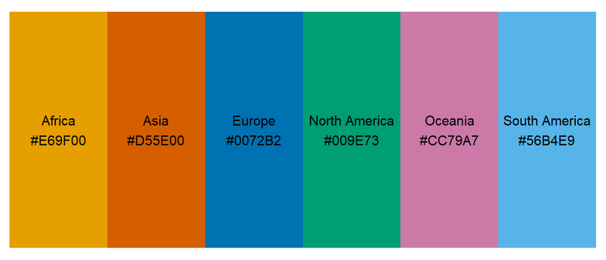

Figure 1: Colour scheme used to represent the continents in the following figures

```r
continent_colors <- c(
  "Africa"        = "#E69F00",  # orange
  "Asia"          = "#D55E00",  # rouge-orangé
  "Europe"        = "#0072B2",  # bleu
  "North America" = "#009E73",  # vert
  "South America" = "#56B4E9",  # bleu clair
  "Oceania"       = "#CC79A7"   # violet
)


ggplot(
  data.frame(
    continent = names(continent_colors),
    color = continent_colors
  ),
  aes(x = continent, y = 1, fill = continent)
) +

  geom_tile() +

  scale_fill_manual(values = continent_colors) +

  geom_text(
    aes(label = paste0(continent, "\n", color)),
    size = 4
  ) +

  theme_void() +

  theme(legend.position = "none")
```

## 1.2 Global overview

This first subsection provides a global overview of where observations are located. The goal is twofold: first, to visualize the overall spatial coverage of the dataset and assess which regions of the world are represented; second, to quantify this coverage at the continent level in order to detect potential imbalances in sampling effort. Figure 2 projects every observation on a world map, colored by continent, offering a first visual impression of the dataset’s geographical spread. Figure 3 then complements this map with a quantitative summary, showing the total number of observations recorded per continent. Finally, Figure 4 goes one step further by highlighting areas of high and low observation density within continents, revealing local concentrations that a simple point map or continent-level count cannot capture on their own. For instance, distinguishing a continent with many observations spread evenly across its territory from one where the same volume of observations is concentrated in a few localized hotspots.

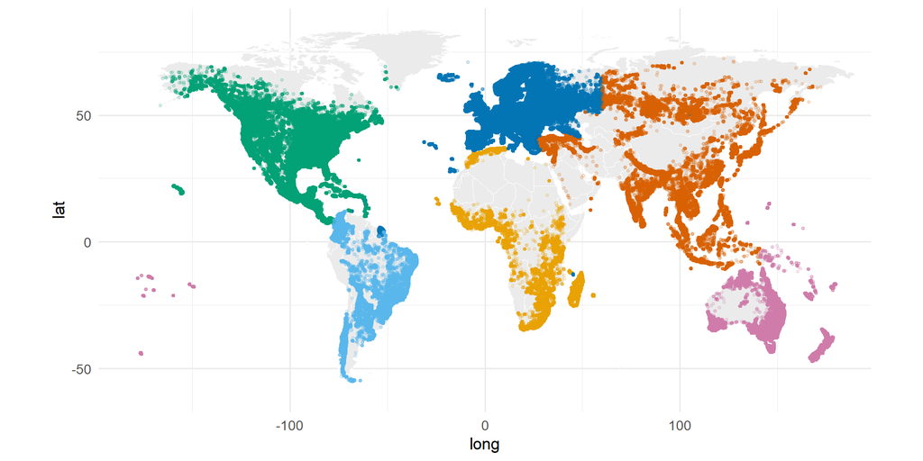

Figure 2: Geographical projection of observations by continent

```r
world_map <- map_data("world")
world_map <- world_map[world_map$region != "Antarctica",]


 ggplot() +

  geom_polygon(data = world_map,
               aes(long, lat, group = group),
               fill = "grey92", colour = "white", linewidth = 0.1) +

  geom_point(data = df,
             aes(longitude, latitude, colour = continent),
             alpha = 0.15, size = 0.8) +

  scale_color_manual(values = continent_colors, guide = "none") +

  coord_fixed(1.3, xlim = c(-180, 180), ylim = c(-60, 85)) +

  theme_minimal(base_size = 13)
```

Figure 2 shows a strongly uneven geographical coverage of observations. North America (green) and Europe (blue) display a dense, near-continuous coverage, closely following major population centers and road networks (a pattern typical of citizen science platforms like iNaturalist, where sampling effort is driven by observer density rather than tree distribution alone). Asia (orange) covers a considerable geographical extent, but coverage is markedly uneven: it is dense in East Asia, India, and along the Trans-Siberian corridor, yet visibly sparse across Central Asia and Siberia’s interior. Africa (yellow) shows a similar contrast, with observations concentrated in South Africa, East Africa, and coastal West Africa, while the Congo Basin and the Sahara remain largely unsampled. South America (light blue) is dominated by coastal Brazil and the Andean corridor, with the Amazon interior almost entirely absent from the dataset despite hosting one of the highest levels of tree biodiversity on Earth. Oceania (pink) is essentially limited to Australia’s populated coastline and a scattering of Pacific islands. Overall, this map already suggests that observation density mirrors human accessibility and citizen-science activity more closely than it reflects actual tree biodiversity (a hypothesis further examined in the following density map Figure 4).

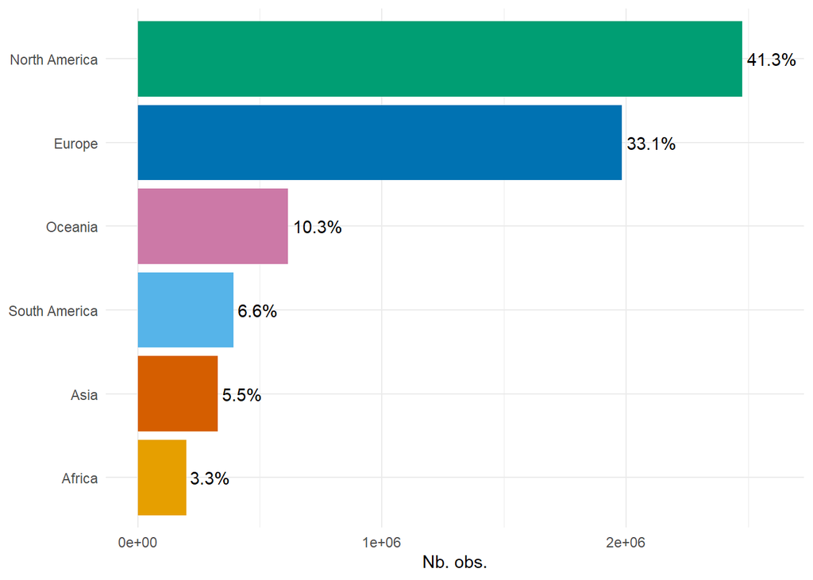

Figure 3: Total number of observations by continent

```r
df_n_obs <- df %>%
  count(continent, sort = TRUE) %>%
  mutate(
    pourcentage = n / sum(n),
    label = scales::percent(pourcentage, accuracy = 0.1)
  )


ggplot(df_n_obs, aes(x = reorder(continent, n), y = n)) +

  geom_col(aes(fill = continent)) +

  scale_fill_manual(values = continent_colors) +

  geom_text(
    aes(label = label),
    hjust = -0.1
  ) +

  expand_limits(y = max(df_n_obs$n) * 1.05) +

  coord_flip() +

  labs(
    x = NULL,
    y = "Nb. obs."
  ) +

  theme_minimal() +

  theme(legend.position = "none")
```

Figure 3 quantifies the imbalance already suggested by Figure 2. North America and Europe together account for 74.4% of all observations (41.3% and 33.1% respectively), despite representing only a fraction of the world’s land area and tree biodiversity. Oceania follows at 10.3%, largely driven by Australia, before a sharp drop to South America (6.6%), Asia (5.5%) and Africa (3.3%). This ranking reveals an important nuance compared to the previous map. Although Asia appeared visually extensive in Figure 2 (spanning a wide longitudinal range with a dense cluster of points), it accounts for only 5.5% of total observations, far below Europe or North America. This apparent contradiction is simply a matter of scale: individual points can appear numerous and spread out on a map while still representing a small share of a dataset containing several million observations overall. This illustrates why the two figures are complementary. The map shows where observations are located, while the bar chart shows how much each region actually contributes to the dataset.

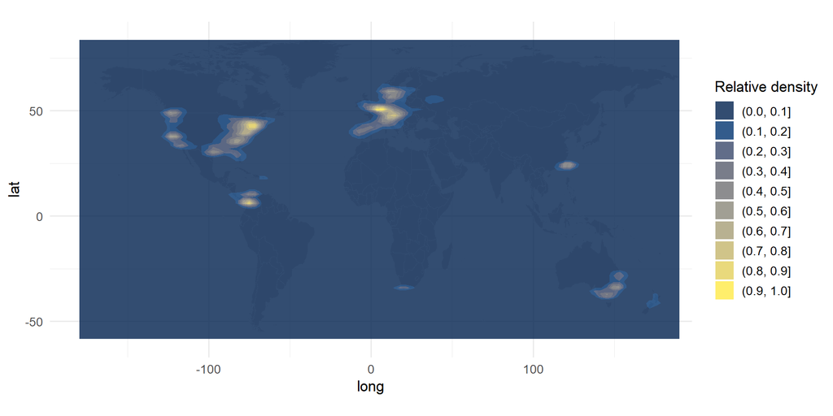

Figure 4: Geographical density of observations

```r
ggplot() +

  # Fond de carte
  geom_polygon(
    data = world_map,
    aes(x = long, y = lat, group = group),
    fill = "grey90", colour = "white", linewidth = 0.1
  ) +

  # Densité 2D
  geom_density_2d_filled(
    data = df,
    aes(x = longitude, y = latitude, fill = after_stat(level)),
    contour_var = "ndensity",
    alpha = 0.8
  ) +

  scale_fill_viridis_d(
    option = "cividis",
    name = "Relative density"
  ) +

  coord_fixed(1.3, xlim = c(-180, 180), ylim = c(-60, 85)) +

  theme_minimal(base_size = 13)
```

Figure 4 confirms and refines the pattern already observed in the previous two figures by revealing that observations are not only concentrated on certain continents, but highly clustered within a small number of localized hotspots. The most intense concentration is found in Western Europe (particularly around France, Germany and the United Kingdom), followed closely by the northeastern United States. Secondary hotspots appear along the U.S. West Coast, in Central America, in southeastern Australia, and around Taiwan / southern Japan, while the vast majority of the remaining land surface, including most of Africa, Asia and South America, shows minimal to no density. This concentration pattern reinforces the hypothesis raised earlier: sampling effort appears strongly correlated with population density and citizen-science activity rather than with the underlying distribution of tree biodiversity. Notably, even within high-observation continents such as North America (Figure 3), density is far from uniform. Most observations are concentrated along the East and West coasts, while large inland areas remain comparatively under-sampled.

Together, these three figures paint a consistent picture. The dataset’s geographical coverage reflects observer accessibility and activity far more than actual global tree distribution, a limitation that should be kept in mind, particularly when interpreting taxonomic diversity by continent in the following sections.

## 1.3 Spatial distribution of foliage types

Having established the overall geographical coverage of the dataset, this subsection shifts focus from where observations occur to what is being observed where. Each tree in the dataset is classified into one of four foliage types (Evergreen Broadleaf, Evergreen Needleleaf, Deciduous Broadleaf, or Deciduous Needleleaf). This classification closely tied to climate, since foliage strategy reflects how trees adapt to seasonal variation in temperature and water availability. The goal is therefore to examine whether these foliage types are distributed uniformly across the sampled regions, or whether they follow the climatic gradients expected from ecological theory, and to what extent this pattern can still be observed despite the sampling bias identified previously.

Three complementary perspectives are used to explore this question. Figure 5 first projects observations individually for each foliage type, allowing their geographical range to be visualized directly on a world map. Figure 6 then aggregates this information into a quantitative comparison, showing how foliage composition varies from one continent to another. Finally, Figure 7 moves away from continental boundaries altogether, examining how the density of each foliage type is distributed along a continuous latitudinal gradient. This perspective is particularly relevant here, since climate (and therefore foliage strategy) is primarily structured by latitude rather than by administrative continental divisions.

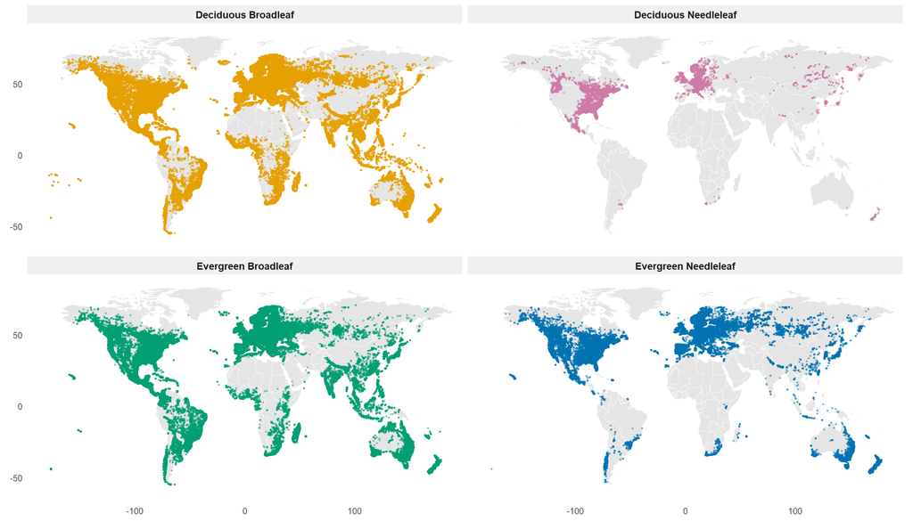

Figure 5: Geographical distribution by type of foliage

```r
palette_level0 <- c(
  "Deciduous Broadleaf"  = "#E69F00",
  "Evergreen Broadleaf"  = "#009E73",
  "Evergreen Needleleaf" = "#0072B2",
  "Deciduous Needleleaf" = "#CC79A7"
)


ggplot() +

  geom_polygon(
    data = world_map,
    aes(x = long, y = lat, group = group),
    fill = "grey90", colour = "white", linewidth = 0.1
  ) +

  geom_point(
    data = df,
    aes(x = longitude, y = latitude, colour = level0),
    alpha = 0.35, size = 0.6
  ) +

  scale_colour_manual(values = palette_level0, guide = "none") +

  facet_wrap(~ level0, ncol = 2) +      # une ligne par 2 catégorie

  coord_fixed(1.3, xlim = c(-180, 180), ylim = c(-60, 85)) +

  labs(
    x = NULL, y = NULL
  ) +

  theme_minimal(base_size = 12) +

  theme(
    panel.grid  = element_blank(),
    strip.text  = element_text(face = "bold", size = 11),
    strip.background = element_rect(fill = "grey94", colour = NA)
  )
```

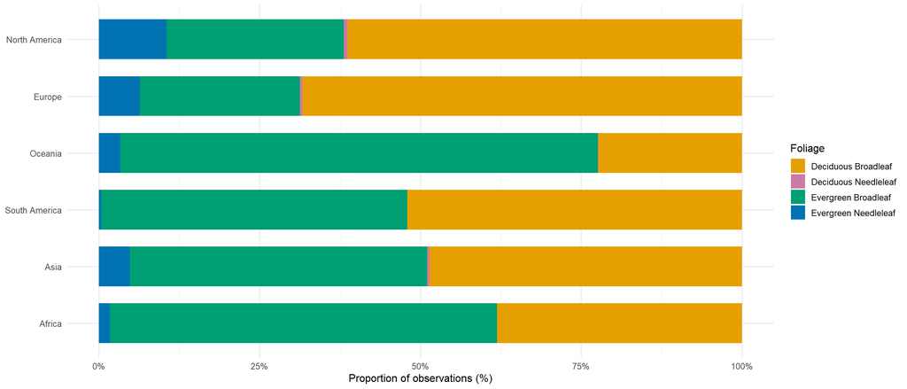

Figure 6: Geographical distribution by type of foliage

```r
df_level0 <- df %>%
  count(continent, level0, name = "n") %>%
  group_by(continent) %>%
  mutate(pct = n / sum(n) * 100) %>%    # proportion pour comparer équitablement
  ungroup() %>%
  mutate(continent = reorder(continent, n, sum))  # tri par total


ggplot(df_level0, aes(x = continent, y = pct, fill = level0)) +

  geom_col(width = 0.7) +

  scale_fill_manual(values = palette_level0, name = "Foliage") +

  scale_y_continuous(labels = scales::label_percent(scale = 1)) +

  coord_flip() +

  labs(
    x = NULL, y = "Proportion of observations (%)"
  ) +

  theme_minimal(base_size = 12) +

  theme(legend.position = "right")
```

Figure 6 complements the previous maps by quantifying, for each continent, the relative composition of foliage types, independent of each continent’s overall sampling volume. A clear contrast emerges between temperate and tropical/subtropical continents. North America and Europe share a similar profile, dominated by Deciduous Broadleaf (around 60–70% of observations), followed by Evergreen Broadleaf as the second-largest category (roughly 25–30%), with Evergreen Needleleaf making up a smaller but still notable share (around 10%), a share not found at comparable levels on any other continent, consistent with the boreal/temperate conifer forests characteristic of these regions. Oceania and Africa, by contrast, are clearly dominated by Evergreen Broadleaf, which accounts for the majority of observations in both continents (over 75% in Oceania, around 60% in Africa), with Deciduous Broadleaf as a smaller secondary category. South America and Asia present an intermediate profile, with Evergreen Broadleaf and Deciduous Broadleaf nearly evenly split at close to 50% each, suggesting that these two continents span a broader mix of climatic zones, from tropical to temperate, rather than being dominated by a single climate regime. Across all four of these continents, Evergreen Needleleaf drops to a marginal share compared to North America and Europe, and Deciduous Needleleaf is nearly absent everywhere except for a very thin presence in North America, Europe, and Asia, consistent with the highly restricted geographical range already observed in Figure 5. This continent-level breakdown reinforces the latitudinal pattern suggested by the maps: continents located predominantly at temperate latitudes (North America, Europe) show a foliage composition weighted toward deciduous and needleleaf strategies, while continents dominated by tropical or subtropical land area (Oceania, Africa) are dominated by evergreen broadleaf species, with South America and Asia sitting in between due to their wider climatic range. This distinction by continent, however, remains an approximation, since large countries such as the United States or China span multiple climatic zones. This limitation is directly addressed by Figure 7, which examines this relationship along a continuous latitudinal axis rather than through continental boundaries.

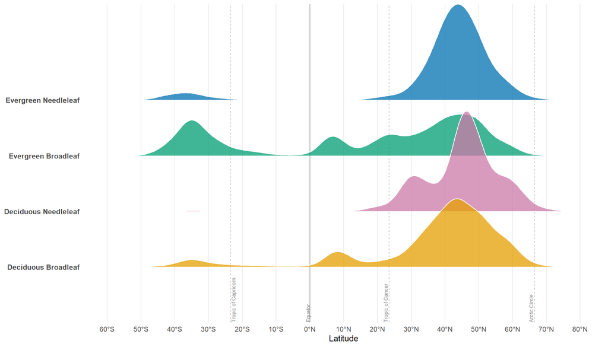

Figure 7: Distribution of foliage types by latitude

```r
# Ridge plot
ggplot(df, aes(x = latitude, y = level0, fill = level0)) +

  # Lignes de repère climatiques (avant les courbes pour qu'elles passent dessous)
  geom_vline(xintercept = 0,    colour = "grey60", linewidth = 0.5, linetype = "solid") +
  geom_vline(xintercept = 23.5, colour = "grey70", linewidth = 0.4, linetype = "dashed") +
  geom_vline(xintercept = -23.5,colour = "grey70", linewidth = 0.4, linetype = "dashed") +
  geom_vline(xintercept = 66.5, colour = "grey70", linewidth = 0.4, linetype = "dashed") +

  # Courbes de densité avec dégradé de transparence (gradient sous la courbe)
  geom_density_ridges(
    aes(fill = level0),
    alpha       = 0.75,
    scale       = 1.8,         # chevauchement entre les courbes (1 = pas de chevauchement)
    rel_min_height = 0.005,    # coupe les queues très faibles
    bandwidth   = 3,           # lissage en degrés de latitude
    colour      = "white",
    linewidth   = 0.6
  ) +

  # Annotations des zones climatiques
  annotate("text", x = 0,     y = 0, label = "Equator",       angle = 90,
           vjust = 0, hjust=0, size = 3, colour = "grey50") +
  annotate("text", x = 23.5,  y = 0, label = "Tropic of Cancer", angle = 90,
           vjust = -0.4, hjust=0, size = 3, colour = "grey55") +
  annotate("text", x = -23.5, y = 0, label = "Tropic of Capricorn", angle = 90,
           vjust =  1.2, hjust=0, size = 3, colour = "grey55") +
  annotate("text", x = 66.5,  y = 0, label = "Arctic Circle", angle = 90,
           vjust = -0.4, hjust=0, size = 3, colour = "grey55") +

  scale_fill_manual(values = palette_level0, guide = "none") +

  scale_x_continuous(
    breaks = seq(-60, 80, by = 10),
    labels = function(x) paste0(abs(x), ifelse(x >= 0, "°N", "°S")),
    limits = c(-60, 80)
  ) +

  labs(
    x        = "Latitude",
    y        = NULL
  ) +

  theme_minimal(base_size = 14) +

  theme(
    panel.grid.minor   = element_blank(),
    panel.grid.major.y = element_blank(),
    axis.text.y        = element_text(face = "bold", size = 12),
    plot.caption       = element_text(size = 9, colour = "grey50", hjust = 0)
  )
```

Figure 7 confirms and refines, with much greater precision, the patterns suggested by the previous map and bar chart. Evergreen Needleleaf (blue) shows the most clearly defined latitudinal signal in the entire figure: a sharp, dominant peak around 45–50°N, with only a small secondary bump around 30–40°S, confirming that this foliage type is overwhelmingly associated with Northern Hemisphere temperate/boreal latitudes, with a much smaller presence in the Southern Hemisphere’s temperate zone. Deciduous Needleleaf (pink) is similarly concentrated at high northern latitudes, with a pronounced peak around 45–55°N and virtually no presence in the Southern Hemisphere. Its distribution is the narrowest and most latitude-restricted of the four foliage types, consistent with its very limited geographical range observed in Figure 5. Deciduous Broadleaf (orange) is dominated by a large peak around 45–50°N, overlapping closely with the two needleleaf types, alongside a much smaller secondary bump near 10°N and a minor bump around 30°S. Evergreen Broadleaf (green) stands out as the most latitudinally spread category, with density visible almost continuously from 40°S to 50°N, including a distinct concentration in the tropical band (0–20°N) that is more pronounced than for the other three types, plus a bump around 30–40°S and a peak around 45–50°N that overlaps with Deciduous Broadleaf. This last point directly resolves the ambiguity raised in Figure 5 and Figure 6: while Deciduous Broadleaf and Evergreen Broadleaf appeared to occupy similar geographical ranges at the continent level, this ridge plot shows they are only partially overlapping in latitude. Evergreen Broadleaf is the only foliage type with a substantial tropical presence, while Deciduous Broadleaf, like both needleleaf types, remains overwhelmingly concentrated in the temperate Northern Hemisphere. This confirms that latitude (more than continental identity) is the primary driver structuring the geographical distribution of foliage types in this dataset, consistent with ecological expectations linking foliage strategy to climate.

## 1.4 Taxonomic richness by continent

This subsection turns from the spatial and climatic distribution of foliage types to a different question: “how much taxonomic diversity does each continent actually contain ?” This question, however, cannot be answered directly by simply counting the number of distinct species or genera observed per continent, precisely because of the sampling imbalance identified in the first subsection of this report. A continent with more observations is mechanically more likely to have recorded more distinct taxa, even if its underlying biodiversity is not necessarily higher. Comparing raw taxonomic counts between continents therefore risks conflating genuine biodiversity differences with differences in sampling effort alone.

Three complementary views are used to address this issue. Table 2 first reports the raw number of distinct taxa recorded per continent, providing a simple numerical summary of the dataset’s taxonomic content. Figure 8 then visualizes these same raw counts as a bar chart, making it easier to compare continents at a glance, while keeping in mind that, at this stage, these values remain directly influenced by each continent’s sampling volume, as shown in Figure 3. Finally, Figure 9 addresses this limitation directly through rarefaction curves, which estimate the expected number of unique species as a function of sample size, allowing continents to be compared on an equal footing regardless of how many observations were actually collected for each.

```r
tableau_taxons <- df %>%
  filter(!is.na(continent)) %>%
  group_by(continent) %>%
  summarise(
    Foliage = n_distinct(level0),
    Families = n_distinct(level1_family),
    Genus   = n_distinct(level2_genus),
    Species  = n_distinct(level3_species),
    Complete_taxons = n_distinct(paste(
      level1_family,
      level2_genus,
      level3_species,
      sep = "_"
    )),
    .groups = "drop"
  )


kable(tableau_taxons)
```

| continent | Foliage | Families | Genus | Species | Complete_taxons |
| --- | --- | --- | --- | --- | --- |
| Africa | 4 | 168 | 987 | 3831 | 3831 |
| Asia | 4 | 180 | 958 | 3809 | 3809 |
| Europe | 4 | 173 | 737 | 2437 | 2437 |
| North America | 4 | 203 | 1219 | 6528 | 6528 |
| Oceania | 4 | 175 | 886 | 4900 | 4900 |
| South America | 4 | 183 | 1099 | 4968 | 4968 |

Table 2: Table of the taxonomic richness by continent

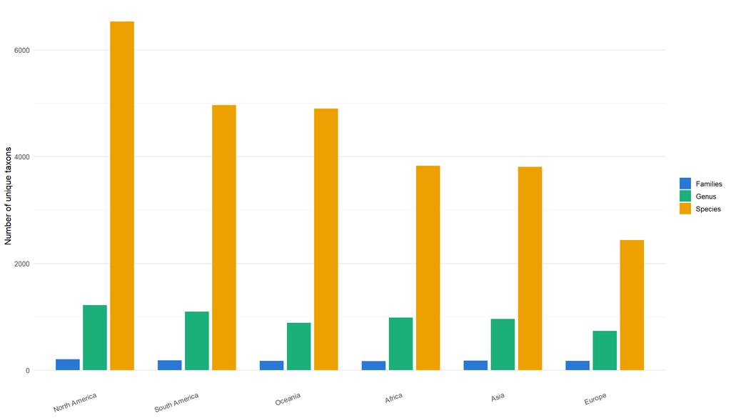

Figure 8: Taxonomic richness by continent (raw values)

```r
richness <- df %>%
  group_by(continent) %>%
  summarise(
    n_familles      = n_distinct(level1_family),
    n_genres        = n_distinct(level2_genus),
    n_especes       = n_distinct(level3_species),
    n_observations  = n()
  ) %>%
  mutate(
    familles_100obs = round(n_familles / n_observations * 100, 1),
    genres_100obs   = round(n_genres   / n_observations * 100, 1),
    especes_100obs  = round(n_especes  / n_observations * 100, 1)
  )

richness_long_raw <- richness %>%
  select(continent, n_familles, n_genres, n_especes) %>%
  pivot_longer(cols = -continent, names_to = "taxon", values_to = "valeur") %>%
  mutate(taxon = recode(taxon,
                        n_familles = "Families",
                        n_genres   = "Genus",
                        n_especes  = "Species"
  ))

# Ordre des taxons et palette cohérente avec le graphique précédent
taxon_levels <- c("Families", "Genus", "Species")
palette_taxons <- c("Families" = "#2a78d6", "Genus" = "#1baf7a", "Species" = "#eda100")

richness_long_raw <- richness_long_raw %>%
  filter(!is.na(continent))
richness_long_raw$taxon  <- factor(richness_long_raw$taxon, levels = taxon_levels)


ggplot(richness_long_raw,
                aes(x = reorder(continent, -valeur), y = valeur, fill = taxon)) +

  geom_col(position = position_dodge(width = 0.8), width = 0.7) +

  scale_fill_manual(values = palette_taxons) +

  labs(
    x = NULL, y = "Number of unique taxons",
    fill = NULL
  ) +

  theme_minimal(base_size = 12) +

  theme(
    axis.text.x = element_text(angle = 20, hjust = 1),
    panel.grid.major.x = element_blank(),
    legend.position = "right"
  )
```

Table 2 and Figure 8 report the raw number of distinct taxa recorded per continent, at three taxonomic levels: family, genus, and species. All six continents show a comparable number of families (168–203), suggesting that the dataset captures a broadly similar range of major taxonomic groups everywhere. This similarity breaks down markedly at finer taxonomic resolution : genus counts range from 737 (Europe) to 1219 (North America), and species counts range even more widely, from 2437 (Europe) to 6528 (North America). North America stands out as the richest continent at every taxonomic level, while Europe consistently ranks lowest.

Comparing this ranking to the observation volume documented in Figure 3 reveals an interesting discrepancy. Europe, despite being the second most heavily sampled continent overall (33.1% of observations), records the lowest species richness of all six continents (even lower than Africa and Asia, which together account for less than 9% of total observations). Conversely, South America and Oceania, which together represent under 17% of observations, show species counts (4968 and 4900 respectively) roughly double that of Europe, despite Europe having been sampled nearly four times more intensively.

This pattern suggests that raw taxonomic richness, as shown here, is not simply proportional to sampling volume, but it does not yet establish whether these differences reflect genuine biodiversity patterns or are still partly shaped by uneven sampling effort within each continent. A question addressed directly by the rarefaction analysis in Figure 9.

**Methodological note :** Rarefaction curves are obtained through repeated random subsampling. For a given continent, a subset of n observations is drawn at random (without replacement) from all its recorded observations, and the number of distinct species present in that subset is counted. This process is repeated many times for each sample size n, and the results are averaged to produce a smooth expected curve. This is repeated for increasing values of n, from a small sample up to the full number of observations available for that continent, producing one curve per continent.

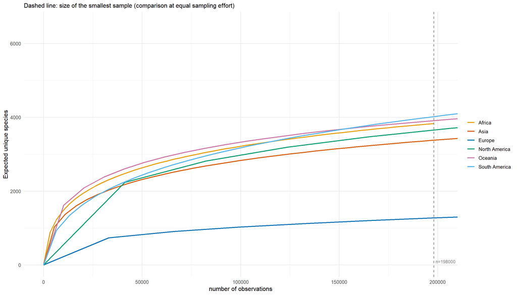

Figure 9: Rarefaction curves by continent

```r
comm_matrix <- df %>%
  st_drop_geometry() %>%
  count(continent, level3_species) %>%
  pivot_wider(names_from = level3_species, values_from = n, values_fill = 0) %>% # Transforme le tableau en une matrice "continent × espèce"
  column_to_rownames("continent") %>%
  as.matrix()

# Calcule le nombre total d'observations par continent et prend le plus petit de ces totaux
min_n <- min(rowSums(comm_matrix))

# Parcourt chaque continent
rare_df <- purrr::map_dfr(rownames(comm_matrix), function(cont) {
  abund <- comm_matrix[cont, ] # Extrait la ligne correspondant au continent
  N <- sum(abund) # nb obs continent
  ns <- unique(c(seq(1, N, by = max(1, N %/% 60)), N)) # série de tailles d'échantillons
  S <- rarefy(matrix(abund, nrow = 1), sample = ns) # calcule le nombre moyen d'espèces attendu si l'on prélève aléatoirement n observations
  tibble(continent = cont, n = ns, S = as.numeric(S))
})


ggplot(rare_df, aes(x = n, y = S, color = continent)) +

  geom_line(linewidth = 1) +

  geom_vline(xintercept = min_n, linetype = "dashed", color = "grey50") +

  annotate("text", x = min_n, y = 0,
           label = paste0("n=", min_n),
           vjust = -0.5, hjust = -0.1, size = 3, color = "grey50") +

  scale_colour_manual(values = continent_colors) +

  labs(
    subtitle = "Dashed line: size of the smallest sample (comparison at equal sampling effort)",
    x = "number of observations",
    y = "Expected unique species",
    color = NULL
  ) +

  coord_cartesian(xlim = c(0, 200000)) +

  theme_minimal(base_size = 12)
```

Figure 9 delivers the central result of this subsection, and substantially revises the picture suggested by the raw counts in Figure 8. At the shared sampling effort marked by the dashed line (n=198,000, the size of Africa’s full sample), the ranking of continents changes considerably. Oceania and South America emerge as the most diverse, both reaching close to 4,000 expected unique species, closely followed by Africa (around 3,900). North America and Asia form an intermediate group (roughly 3,700 and 3,400 respectively), while Europe remains clearly the least diverse continent, with only around 1,300 expected species (less than a third of the leading continents, despite being the second most heavily sampled continent overall).

The most striking result of this analysis concerns North America. While it recorded by far the highest raw species count in Figure 8 (6,528 species), this advantage all but disappears once sampling effort is equalized. Its rarefaction curve is overtaken by Oceania, South America, and Africa well before reaching the comparison point. This confirms that North America’s apparent leadership in raw richness was largely an artifact of its considerably larger sample size (Figure 3), rather than evidence of genuinely higher tree diversity.

Europe presents the opposite and arguably more informative case. Its rarefaction curve remains consistently and substantially below all other continents across the entire range shown, including at very small sample sizes where all continents should, in principle, be more directly comparable. This indicates that Europe’s low species richness is not primarily a sampling artifact (as it was heavily sampled overall) but likely reflects a genuine ecological pattern, plausibly linked to lower tree species diversity in temperate European forests compared to the other regions.

## 1.5 Changes in the distribution over time

The two previous subsections examined the spatial and taxonomic distribution of observations as a static snapshot, without considering when this data was collected. However, given the strong reliance on citizen-science platforms such as iNaturalist, sampling effort is unlikely to have remained constant over time. It has likely grown alongside the adoption of these platforms, and may have expanded geographically as new contributors joined from previously under-sampled regions. This final subsection therefore introduces the temporal dimension, examining how both the volume and the geographical spread of observations have evolved over the years.

Figure 10 first tracks the total number of observations recorded each year, alongside the number of distinct countries contributing data, allowing global growth in sampling effort to be distinguished from genuine geographical expansion.

Figure 11 then breaks this trend down by continent, revealing whether this growth has been shared evenly across regions or driven primarily by a subset of continents, which would in turn affect the balance of the geographical biases identified earlier.

Finally, Figure 12 brings the temporal and spatial dimensions together, mapping observations over successive two-year periods to directly visualize how the geographical coverage of the dataset has expanded, or remained concentrated, over time.

Taken together, these figures assess whether the spatial imbalances observed in the previous subsections are a stable, structural feature of the dataset, or whether they are progressively narrowing as data collection continues to grow.

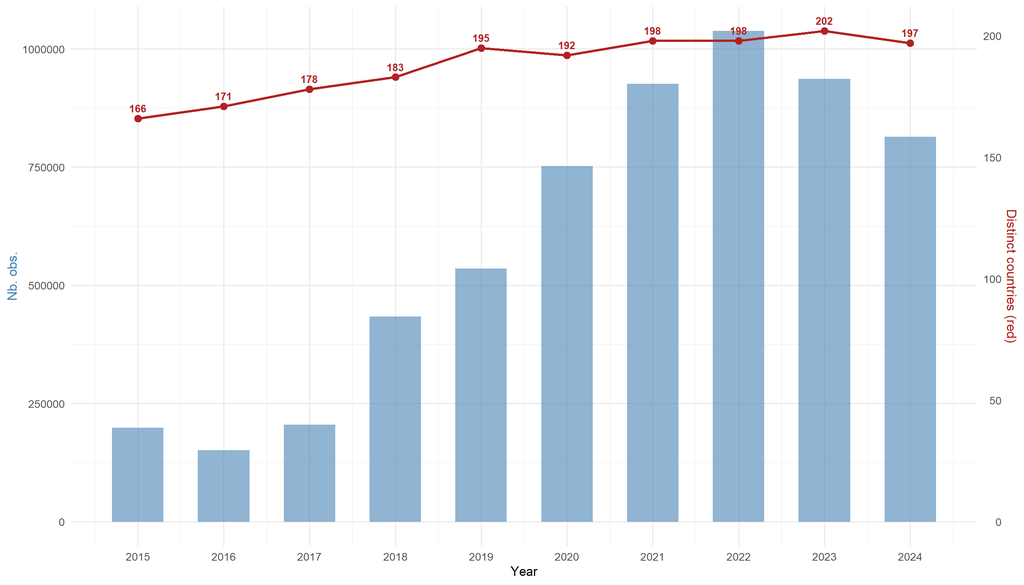

Figure 10: Trends in data collection over time

```r
summary_year <- df %>%
  group_by(year) %>%
  summarise(
    n_obs      = n(),
    n_pays     = n_distinct(country_code),
    .groups    = "drop"
  )

coeff <- max(summary_year$n_obs) / max(summary_year$n_pays)


ggplot(summary_year, aes(x = year)) +

  # Barres pour le volume d'observations
  geom_col(aes(y = n_obs), fill = "steelblue", alpha = 0.6, width = 0.6) +

  # Ligne pour le nombre de pays distincts (axe secondaire)
  geom_line(aes(y = n_pays * coeff), colour = "firebrick", linewidth = 1.2) +

  geom_point(aes(y = n_pays * coeff), colour = "firebrick", size = 3) +

  # Annotations directes sur les points clés
  geom_text(
    aes(y = n_pays * coeff, label = n_pays),
    vjust = -0.8, colour = "firebrick", size = 3.5, fontface = "bold"
  ) +

  scale_x_continuous(breaks = 2015:2024) +

  scale_y_continuous(
    name = "Nb. obs.",
    sec.axis = sec_axis(~ . / coeff, name = "Distinct countries (red)")
  ) +

  labs(
    x        = "Year"
  ) +

  theme_minimal(base_size = 13) +

  theme(
    axis.title.y.right = element_text(colour = "firebrick"),
    axis.title.y.left  = element_text(colour = "steelblue")
  )
```

For his part, the number of distinct countries contributing observations (red line) shows an upward trend, growing from 166 in 2015 to over 198 by 2021, before stabilizing around 197–202 through 2024. This increase indicates a genuine geographical expansion of data collection over time, to the point where the dataset now includes at least one observation from nearly every country in the world (since there are only around 200 countries globally). This near-complete country coverage, however, should be interpreted carefully alongside the sharp rise in observation volume over the same period. The fact that almost every country is represented does not imply that sampling effort is evenly distributed within or between them. A single observation in a given country carries very different weight than the hundreds of thousands recorded annually in others, such as those in North America or Europe.

Whether this recent growth in volume has been accompanied by a more even distribution across continents, or remains concentrated in already-dominant regions, is examined more directly in the next figure (Figure 11).

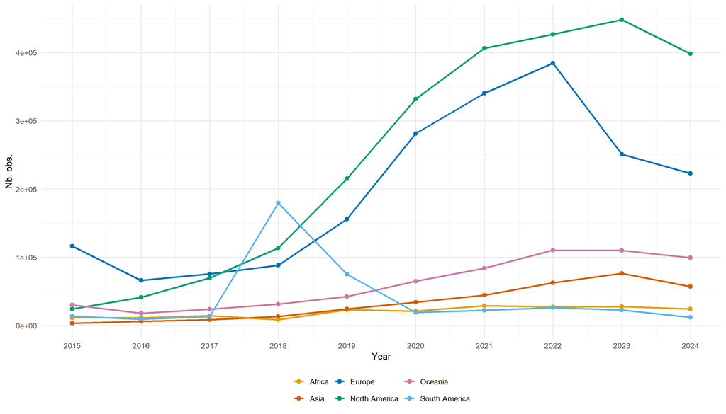

Figure 11: Collection volume by continent and by year

```r
summary_continent <- df %>%
  count(year, continent, name = "n")


ggplot(summary_continent, aes(x = year, y = n, colour = continent)) +

  geom_line(linewidth = 1.1) +

  geom_point(size = 2.5) +

  scale_colour_manual(values = continent_colors, name = NULL) +

  scale_x_continuous(breaks = 2015:2024) +

  labs(
    x = "Year", y = "Nb. obs."
  ) +

  theme_minimal(base_size = 13) +

  theme(legend.position = "bottom")
```

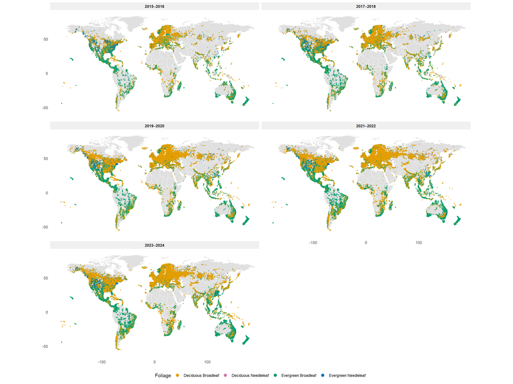

Figure 12: Geographical scope of data collection by period (5 two-year periods)

```r
df_periode <- df %>%
  mutate(periode = case_when(
    year %in% c(2015, 2016) ~ "2015–2016",
    year %in% c(2017, 2018) ~ "2017–2018",
    year %in% c(2019, 2020) ~ "2019–2020",
    year %in% c(2021, 2022) ~ "2021–2022",
    year %in% c(2023, 2024) ~ "2023–2024"
  )) %>%
  mutate(periode = factor(periode, levels = c(
    "2015–2016", "2017–2018", "2019–2020", "2021–2022", "2023–2024"
  )))


ggplot() +

  geom_polygon(
    data = world_map,
    aes(x = long, y = lat, group = group),
    fill = "grey88", colour = "white", linewidth = 0.08
  ) +

  geom_point(
    data = df_periode,
    aes(x = longitude, y = latitude, colour = level0),
    alpha = 0.4, size = 0.5
  ) +

  scale_colour_manual(values = palette_level0, name = "Foliage") +

  facet_wrap(~ periode, ncol = 2) +

  coord_fixed(1.3, xlim = c(-180, 180), ylim = c(-60, 85)) +

  labs(
    x = NULL, y = NULL
  ) +

  theme_minimal(base_size = 11) +

  theme(
    panel.grid       = element_blank(),
    legend.position  = "bottom",
    strip.text       = element_text(face = "bold"),
    strip.background = element_rect(fill = "grey94", colour = NA)
  ) +

  guides(colour = guide_legend(
    override.aes = list(alpha = 1, size = 3)   # rend la légende lisible malgré alpha faible
  ))
```

Figure 12 provides a direct spatial confirmation of the trends identified in the two previous figures, while also introducing an additional dimension: foliage type (Evergreen Broadleaf, Evergreen Needleleaf, Deciduous Broadleaf). Across all five periods, the overall geographical footprint of the dataset remains remarkably stable. The same broad regions (North America, Europe, coastal South America, parts of Africa and Southeast Asia/Oceania) are already represented as early as 2015–2016, with no major new region appearing in later periods. This is consistent with the near-total country coverage observed in Figure 10: geographical breadth was established early, and subsequent growth in volume (Figure 11) has taken the form of densification within already-sampled areas rather than expansion into new ones. This densification is visually apparent when comparing early and recent periods: point coverage becomes progressively denser and more continuous over North America and Europe, particularly for deciduous broadleaf (orange) and evergreen broadleaf (green) foliage, while regions such as central Africa, the Amazon interior, and Central Asia remain visibly sparse throughout all five periods, showing little to no improvement over the decade.

Overall, this final figure reinforces the central finding of this subsection: the sampling bias identified earlier in the report is not a transient artifact of an early, immature dataset that has since been corrected, but a structural and persistent feature that has remained stable over the full ten-year period covered by the data.